# CL Final Project: NYPD Shooting Incident Report

Catherine Lebastard

9/11/2021

## About the data

The data comes from the City of New York website: https://catalog.data.gov/dataset. The dataset used is “NYPD Shooting Incident Data (History)”, and it lists every shooting incident that occurred in NYC going back to 2006 through the end of the previous calendar year.

## Step 1 - Import the project dataset

*Imports the shooting project dataset in a reproducible manner.*

1. Install the library tidyverse or load it

   ```r
   if (!require(tidyverse)) install.packages("tidyverse");
   library(tidyverse)
   library(lubridate)
   ```

2. Read the NYPD dataset

   ```r
   urlNYPD = "https://data.cityofnewyork.us/api/views/833y-fsy8/rows.csv?accessType=DOWNLOAD"
   shooting_NY <- read_csv(urlNYPD)
   ```

## Step 2 - Tidy and Transform your data

*Add a summary of the data and clean up the dataset by changing appropriate variables to factor and data types and getting rid of any columns not needed.*

```r
shooting_NY <- shooting_NY %>%
  mutate(OCCUR_DATE = mdy(OCCUR_DATE)) %>%
  mutate(BORO = fct_recode(BORO)) %>%
  mutate(PRECINCT = factor(PRECINCT)) %>%
  mutate(JURISDICTION_CODE = factor(JURISDICTION_CODE)) %>%
  mutate(PERP_AGE_GROUP = factor(PERP_AGE_GROUP)) %>%
  mutate(PERP_SEX = fct_recode(PERP_SEX)) %>%
  mutate(PERP_RACE = fct_recode(PERP_RACE)) %>%
  mutate(VIC_AGE_GROUP = fct_recode(VIC_AGE_GROUP)) %>%
  mutate(VIC_SEX = fct_recode(VIC_SEX)) %>%
  mutate(VIC_RACE = fct_recode(VIC_RACE)) %>%
  select(-c(X_COORD_CD, Y_COORD_CD, Lon_Lat))

shooting_NY$PERP_RACE[shooting_NY$PERP_RACE == 'UNKNOWN'] <- NA
summary(shooting_NY)
```

```
##   INCIDENT_KEY         OCCUR_DATE          OCCUR_TIME
##  Min.   :  9953245   Min.   :2006-01-01   Length:23568
##  1st Qu.: 55317014   1st Qu.:2008-12-30   Class :character
##  Median : 83365370   Median :2012-02-26   Mode  :character
##  Mean   :102218616   Mean   :2012-10-03
##  3rd Qu.:150772442   3rd Qu.:2016-02-28
##  Max.   :222473262   Max.   :2020-12-31
##
##             BORO         PRECINCT     JURISDICTION_CODE LOCATION_DESC
##  BRONX        :6700   75     : 1367   0   :19624        Length:23568
##  BROOKLYN     :9722   73     : 1282   1   :   54        Class :character
##  MANHATTAN    :2921   67     : 1102   2   : 3888        Mode  :character
##  QUEENS       :3527   79     :  920   NA's:    2
##  STATEN ISLAND: 698   44     :  842
##                       47     :  815
##                       (Other):17240
##  STATISTICAL_MURDER_FLAG PERP_AGE_GROUP PERP_SEX
##  Mode :logical           18-24  :5448   F   :  334
##  FALSE:19080             25-44  :4613   M   :13305
##  TRUE :4488              UNKNOWN:3156   U   : 1504
##                          <18    :1354   NA's: 8425
##                          45-64  : 481
##                          (Other):  57
##                          NA's   :8459
##                     PERP_RACE     VIC_AGE_GROUP   VIC_SEX
##  BLACK                   : 9855   <18    : 2525   F: 2195
##  WHITE HISPANIC          : 1961   18-24  : 9000   M:21353
##  BLACK HISPANIC          : 1081   25-44  :10287   U:   20
##  WHITE                   :  255   45-64  : 1536
##  ASIAN / PACIFIC ISLANDER:  120   65+    :  155
##  (Other)                 :    2   UNKNOWN:   65
##  NA's                    :10294
##                            VIC_RACE        Latitude       Longitude
##  AMERICAN INDIAN/ALASKAN NATIVE:    9   Min.   :40.51   Min.   :-74.25
##  ASIAN / PACIFIC ISLANDER      :  320   1st Qu.:40.67   1st Qu.:-73.94
##  BLACK                         :16846   Median :40.70   Median :-73.92
##  BLACK HISPANIC                : 2244   Mean   :40.74   Mean   :-73.91
##  UNKNOWN                       :  102   3rd Qu.:40.82   3rd Qu.:-73.88
##  WHITE                         :  615   Max.   :40.91   Max.   :-73.70
##  WHITE HISPANIC                : 3432
```

## Step 3 - Visualizations and Analysis

*Add at least two different visualizations and some analysis*

### Questions

Question1: Which boroughs are more unsafe than others in NYC from 2006 to 2020?

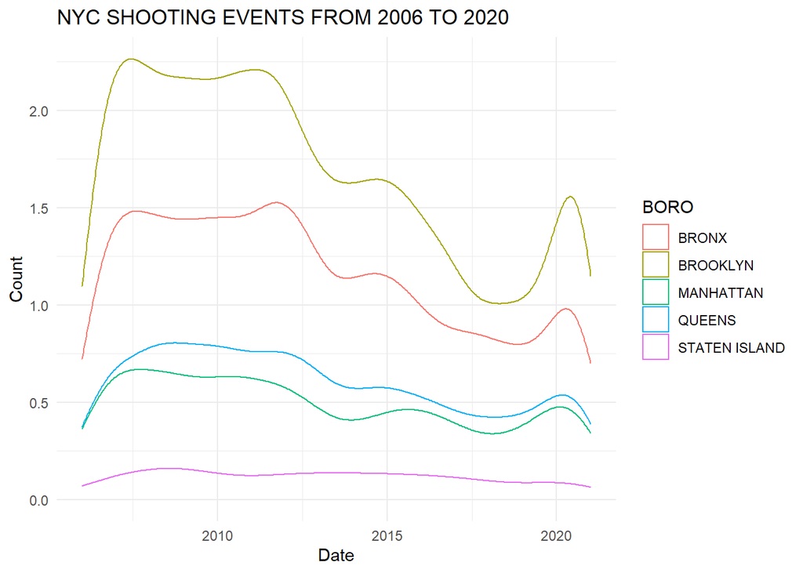

With this visualization, we can answer that Brooklyn is the borough with the highest number of shootings over the years.

Question 2: Which boroughs of New York has the most number of shootings? From those shootings, how many are murder cases?

```r
#Data preparation
shootings_NY_per_boro <- shooting_NY %>% group_by(BORO) %>% summarize(cases = n())
murders_NY_per_boro <- merge(shooting_NY %>% group_by(BORO, STATISTICAL_MURDER_FLAG)
                             %>% summarize(cases = n()),
                             shootings_NY_per_boro, by='BORO', all.x = TRUE)
murders_NY_per_boro <- murders_NY_per_boro %>% rename(cases = cases.x, total_cases = cases.y)
murders_NY_per_boro <- murders_NY_per_boro %>% mutate(pct = round(cases / total_cases * 100, 2))

murders_NY_per_boro
```

```
##             BORO STATISTICAL_MURDER_FLAG cases total_cases   pct
## 1          BRONX                   FALSE  5456        6700 81.43
## 2          BRONX                    TRUE  1244        6700 18.57
## 3       BROOKLYN                   FALSE  7830        9722 80.54
## 4       BROOKLYN                    TRUE  1892        9722 19.46
## 5      MANHATTAN                   FALSE  2409        2921 82.47
## 6      MANHATTAN                    TRUE   512        2921 17.53
## 7         QUEENS                   FALSE  2830        3527 80.24
## 8         QUEENS                    TRUE   697        3527 19.76
## 9  STATEN ISLAND                   FALSE   555         698 79.51
## 10 STATEN ISLAND                    TRUE   143         698 20.49
```

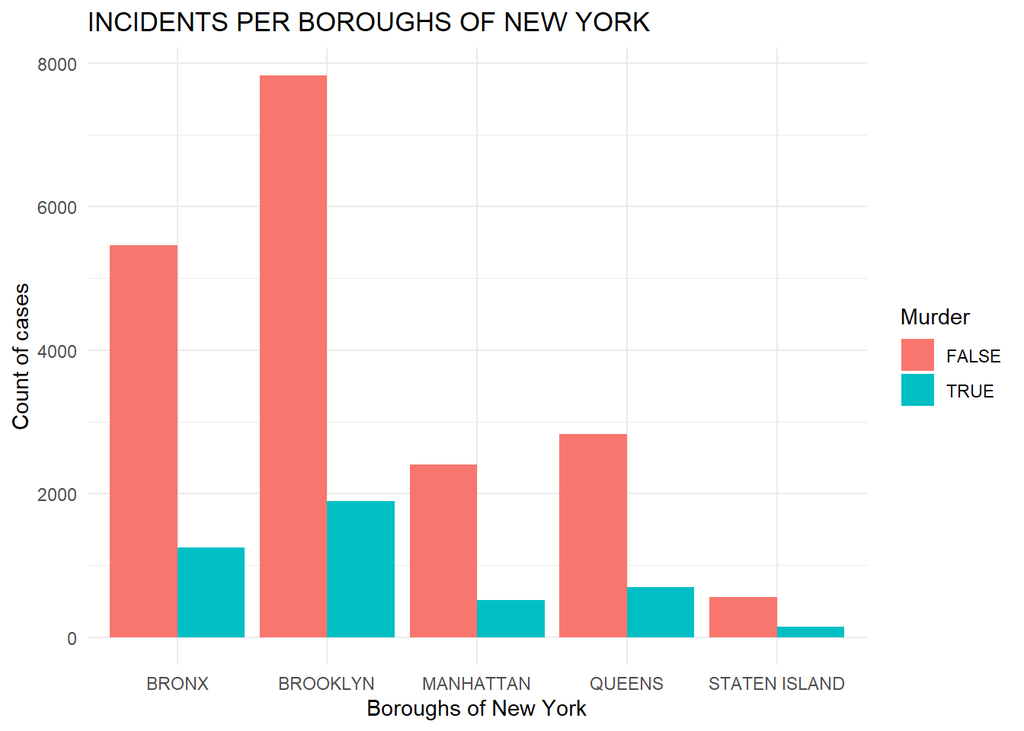

With this prepared data and the visualization, we can answer that Brooklyn has the most number of shootings. It has 1,892 murder cases.

### Analysis

```r
#Perpetrator per race
shootings_NY_per_perp_race <- shooting_NY %>% group_by(PERP_RACE) %>% summarize(cases = n())
shootings_NY_perp_race_vic_race <- merge(shooting_NY %>%
                                  group_by(PERP_RACE, VIC_RACE) %>%
                                  summarize(cases = n()),
                                  shootings_NY_per_perp_race, by='PERP_RACE', all.x = TRUE)
shootings_NY_perp_race_vic_race <- shootings_NY_perp_race_vic_race %>%
  rename(cases = cases.x, total_cases = cases.y)
shootings_NY_perp_race_vic_race <- shootings_NY_perp_race_vic_race %>%
  mutate(pct = round(cases / total_cases * 100, 2))
#Perpetrator per sex
shootings_NY_per_perp_sex <- shooting_NY %>% group_by(PERP_SEX) %>% summarize(cases = n())
shootings_NY_perp_race_vic_sex <- merge(shooting_NY %>%
                                  group_by(PERP_SEX, VIC_SEX) %>%
                                  summarize(cases = n()),
                                  shootings_NY_per_perp_sex, by='PERP_SEX', all.x = TRUE)
shootings_NY_perp_race_vic_sex <- shootings_NY_perp_race_vic_sex %>%
  rename(cases = cases.x, total_cases = cases.y)
shootings_NY_perp_race_vic_sex <- shootings_NY_perp_race_vic_sex %>%
  mutate(pct = round(cases / total_cases * 100, 2))
```

Analyzing the shootings per race

```r
shootings_NY_per_perp_race %>% arrange(desc(cases))
```

```
## # A tibble: 7 x 2
##   PERP_RACE                      cases
##   <fct>                          <int>
## 1 <NA>                           10294
## 2 BLACK                           9855
## 3 WHITE HISPANIC                  1961
## 4 BLACK HISPANIC                  1081
## 5 WHITE                            255
## 6 ASIAN / PACIFIC ISLANDER         120
## 7 AMERICAN INDIAN/ALASKAN NATIVE     2
```

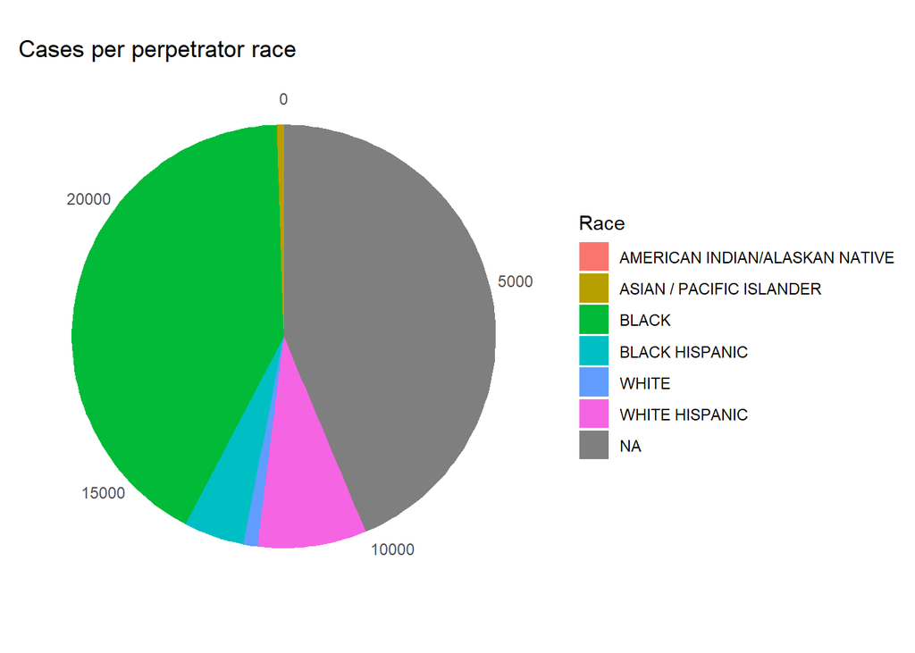

Looking at the race of perpetrators it is immediately visible that there is a huge proportion of unknown values. The 2nd largest group is black, while the smallest one is American Indian/Alaskan native.

Analyzing the shootings per race perpetrator and victim

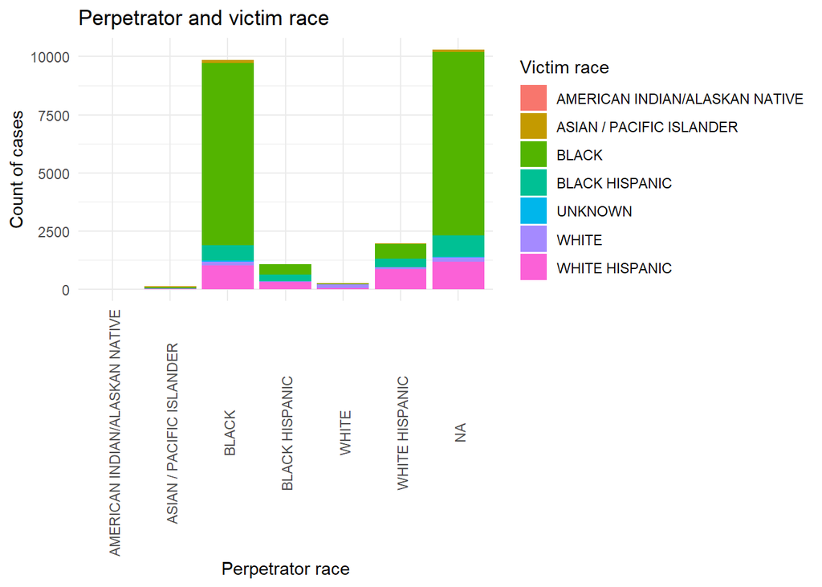

Analyzing the shootings per sex

```r
shootings_NY_perp_race_vic_sex %>% arrange(desc(total_cases), desc(cases))
```

```
##    PERP_SEX VIC_SEX cases total_cases   pct
## 1         M       M 11881       13305 89.30
## 2         M       F  1414       13305 10.63
## 3         M       U    10       13305  0.08
## 4      <NA>       M  7798        8425 92.56
## 5      <NA>       F   619        8425  7.35
## 6      <NA>       U     8        8425  0.09
## 7         U       M  1390        1504 92.42
## 8         U       F   113        1504  7.51
## 9         U       U     1        1504  0.07
## 10        F       M   284         334 85.03
## 11        F       F    49         334 14.67
## 12        F       U     1         334  0.30
```

Looking at the gender is immediately visible that the perpetrator and the victim are males. Very few females are perpetrators attacking another female.

### Model

```r
# Create the murders_NY_per_boro_total dataset
murders_NY_per_boro_Y <- murders_NY_per_boro %>%
filter(STATISTICAL_MURDER_FLAG==TRUE)
murders_NY_per_boro_N <- murders_NY_per_boro %>%
filter(STATISTICAL_MURDER_FLAG==FALSE)
murders_NY_per_boro_total <- left_join(murders_NY_per_boro_Y,murders_NY_per_boro_N, by='BORO') %>%
select(-c(STATISTICAL_MURDER_FLAG.x,STATISTICAL_MURDER_FLAG.y,total_cases.y,pct.x,pct.y)) %>%
rename("cases_murder"="cases.x","cases_no_murder"="cases.y","total_case"="total_cases.x")
```

```r
# Create the Linear regression
mod <- lm(cases ~ total_cases, data = shootings_NY_perp_race_vic_sex)
summary(mod)
```

```
##
## Call:
## lm(formula = cases ~ total_cases, data = shootings_NY_perp_race_vic_sex)
##
## Residuals:
##     Min      1Q  Median      3Q     Max
## -4425.0 -2342.1  -249.3   351.7  7446.0
##
## Coefficients:
##               Estimate Std. Error t value Pr(>|t|)
## (Intercept) -1.313e-12  1.517e+03   0.000    1.000
## total_cases  3.333e-01  1.917e-01   1.739    0.113
##
## Residual standard error: 3506 on 10 degrees of freedom
## Multiple R-squared:  0.2322, Adjusted R-squared:  0.1554
## F-statistic: 3.024 on 1 and 10 DF,  p-value: 0.1127
```

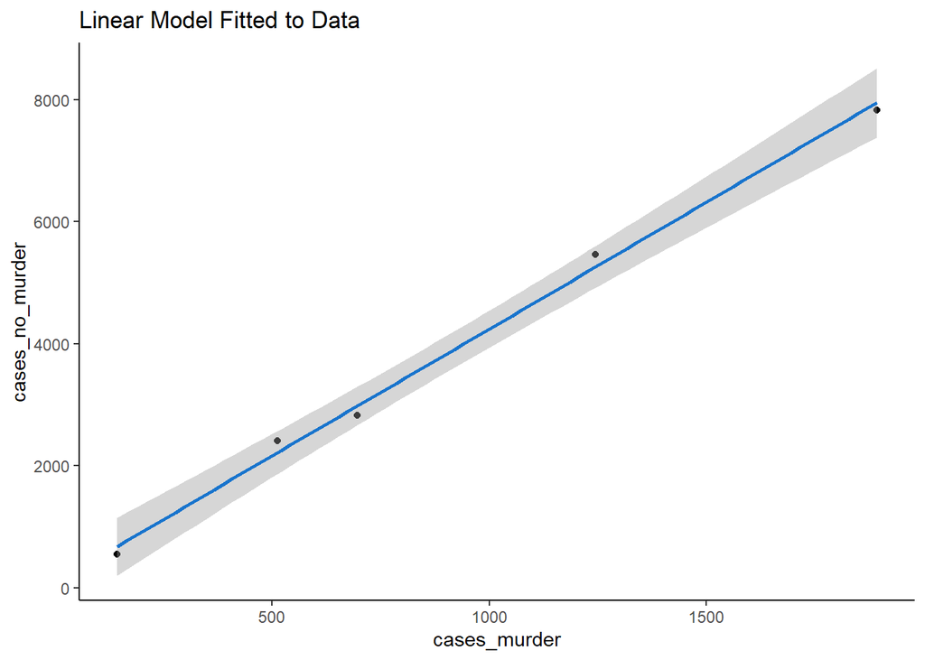

## Step 4 - Add Bias Identification

*Write the conclusion to your project report and include any possible sources of bias.*

In conclusion, Brooklyn is the borough with the highest number of shooting over the years. Also, there is a spike of shooting in the middle of 2020. The number of no murder incidents are higher than the murder incidents. The black race is the dominant one for being the perpetrator and the victim. Moreover, the perpetrator and the victims are males

After reading an article about the safest boroughs to live, it was saying that Brooklyn was one of the safest boroughs to live but the NYPD data shows the opposite. I also assumed that the victims are more likely to be women than men because I watched shows and ads to stop men killing women on the TV. I mitigated this bias by doing this assignment which uses factual data.